# Textbook Analyses 2

Cassie Malcom

2/28/2022

Data cleaning code to build the ehnicity.csv file is in another rmd that stopped working and freezes upon loading into the project.

Total is a new variable that shows the total number of student in 9th through 12th grade for each school district.

Need to get all minorities into one sum. Pivot?

How to get a table like this to scroll on knitting to HTML?

The variable percentW is the percent of white students in a school district; while the variable percentM is the percent of minority students in a school district.

V33 is the fiscal year 2019 fall membership; while V93 is textbook expenditures per school district. Also included the state name abbreviations (STABBR).

Variable V33 (fall membership) matches the student_count variable so don’t need to add the student count from the other data set.

```r
write.csv(tbd_f4, "tbd_f4.csv")
```

Initial draft of p1

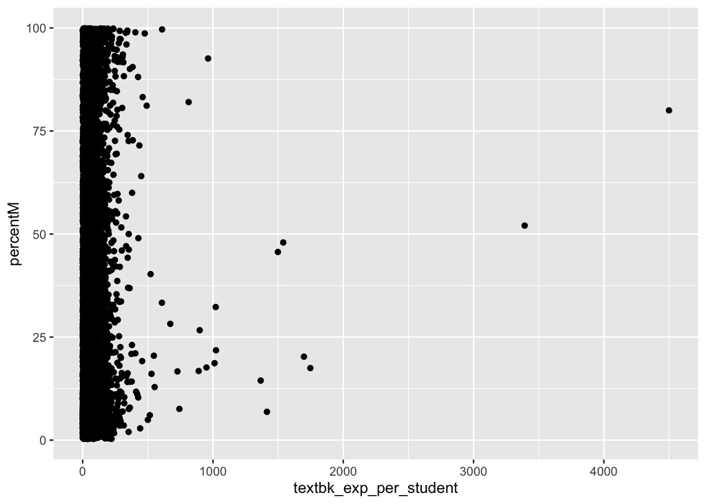

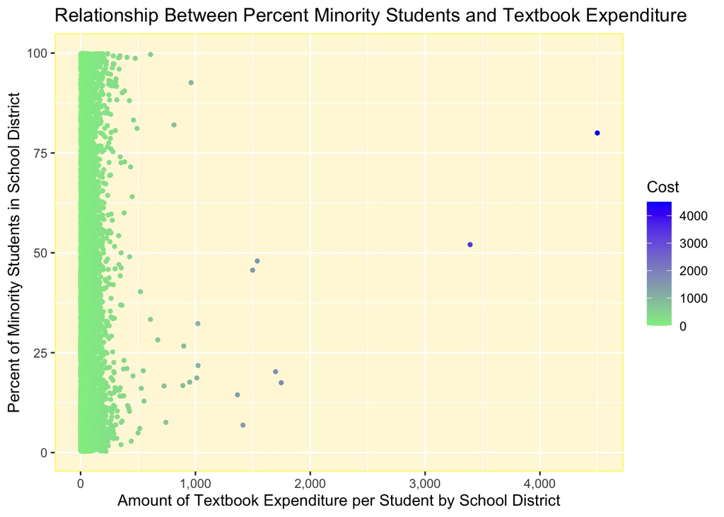

Showing p1 should be sufficient as p2 doesn’t offer any new information.

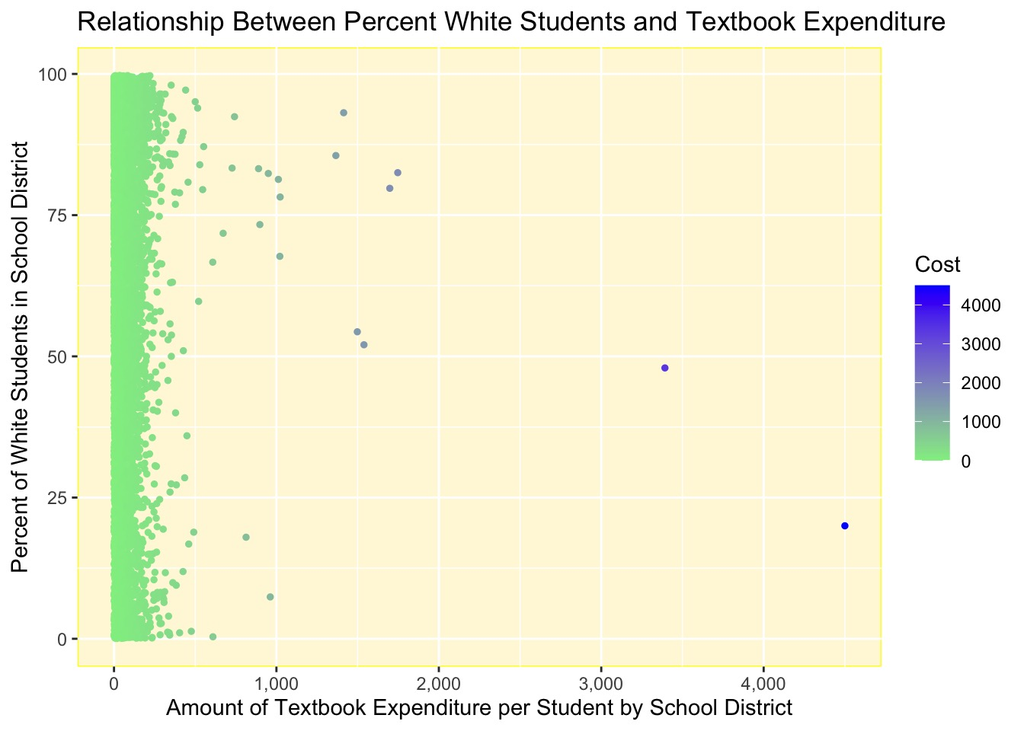

I don’t see any significant correlation though so this might not be a RQ that we want to continue with.

Building a correlation table

Removed print function - see if this works in the dashboard

```
## % latex table generated in R 4.1.2 by xtable 1.8-4 package
## % Fri Mar  4 12:25:35 2022
## \begin{table}[ht]
## \centering
## \begin{tabular}{rllll}
##   \hline
##  & Total Number of Students per District & Textbook Expenditure per Student & Percent of Student Population Identifying as Minority & Percent of Student Population Identifying as White \\
##   \hline
## total &  &  &  &  \\
##   textbk\_exp\_per\_student &  0.00  &  &  &  \\
##   percentM &  0.21*** &  0.05*** &  &  \\
##   percentW & -0.21*** & -0.05*** & -1.00*** &  \\
##    \hline
## \end{tabular}
## \caption{Correlation Table for Textbook Expenditure}
## \end{table}
```

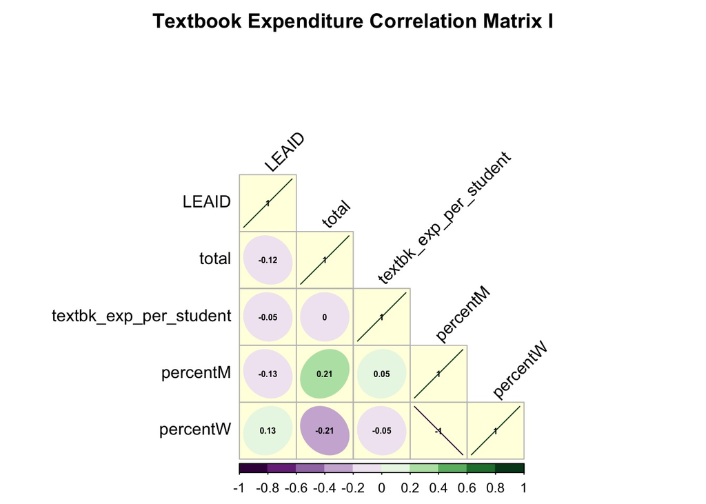

Correlation Matrix - how to change colors, labels, font size? Dislike the red font and larger font size.

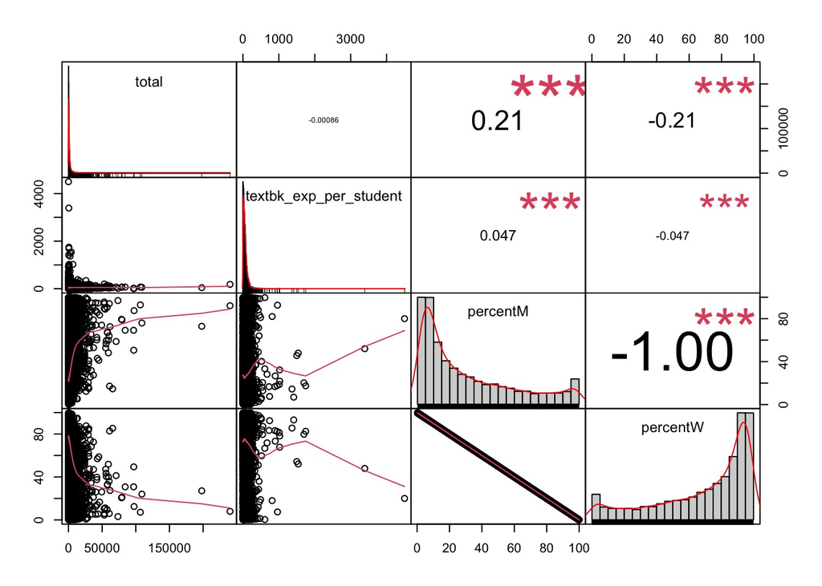

Missing the lines from the scatterplots.

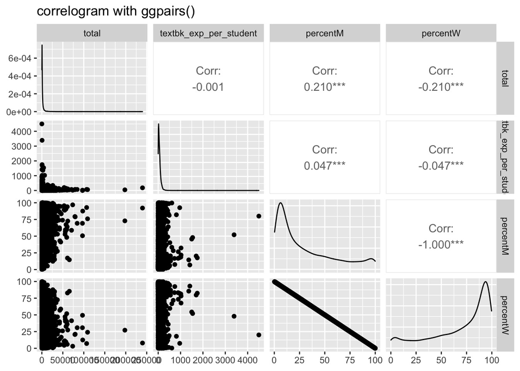

Final Version

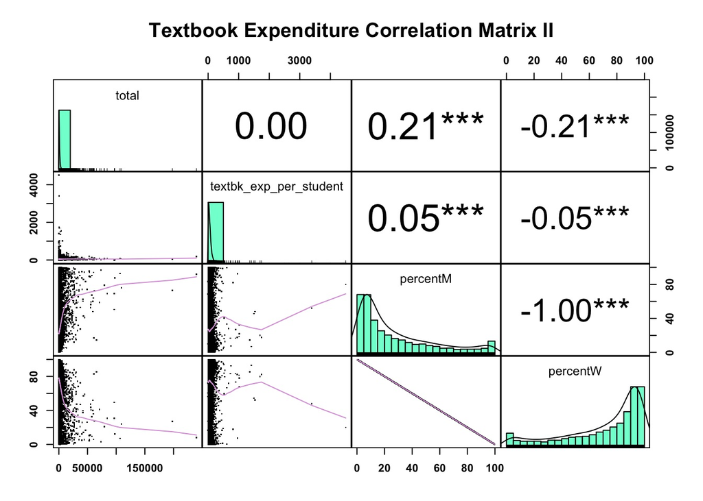

Over 1,200 schools in Oregon that are located in 197 school districts per https://www.oregon.gov/ode/schools-and-districts/Pages/default.aspx#:~:text=There%20are%20more%20than%201%2C200,in%20the%20State%20of%20Oregon.

This code was just to check if GEOID, LEAID, and NCES ID variables are the same number, which they are.

Is there a way to roll over the map and have student population size for each school district pop up? Not thrilled with color yet either.

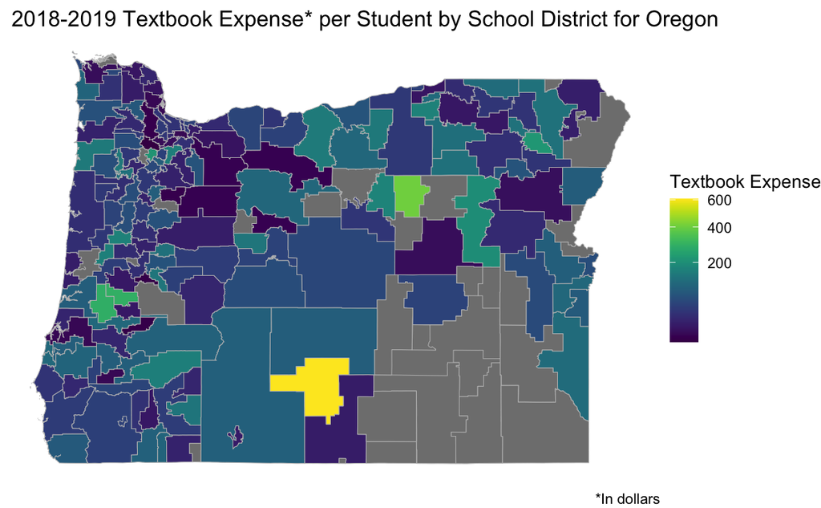

This doesn’t seem to generate any noticable changes from the above plot - DNU.